# data-reanalysis-assignment

Silvy van Kuijk

November 2, 2016

## Elements of Your Report:

You should start your reanalysis report with a short description of the study and of the specific data and reanalyses you will be doing, to orient your reader. Outline (briefly) the goal of the original paper, the data set used, and the analyses conducted, then describe which ones you will replicate. You should also demonstrate how you read in your datafile and show a few lines of raw data in your output (e.g., using `head()`).

I will be looking for you to clearly take your reader through all of the elements of data manipulation, analysis, and, if appropriate, visualization. You should provide as much coding detail, explanation, and output tables as necessary to compare your results to those published!

# Titi monkey call sequences vary with predator location and type

### - by Cäsar, C., Zuberbühler, K., Young, R. J., & Byrne, R. W. [(2013)](http://rsbl.royalsocietypublishing.org/content/9/5/20130535.short).

This paper investigates the alarm calls of the [black-fronted titi monkey](https://upload.wikimedia.org/wikipedia/commons/0/05/Callicebus_nigrifrons_Minas_Gerais.jpg). These small Neotropical primates are known to be hunted by a variety of animals, such as raptors, terrestrial carnovires, and snakes. In a previous study, which you can find [here](http://link.springer.com/article/10.1007/s00265-011-1313-0), Cäsar et al. established that the titis use two main alarm calls upon encountering predators. Alarm call type A is used upon encountering raptors whereas call type B is used when terrestrial predators are spotted. Only rarely is call type C heard, and the authors are not sure of the context in which it is heard.

Some data in this previous study seemed to show that maybe these A and B calls were not only predator-specific, but potentially reveal the predator’s location. In this study the authors explore this hypothesis by presenting the titi monkeys with two different predator types (oncilla vs. caracara) and elevations (terrestrial vs. aerial). (Even though caracaras do not seem likely predators, [suspected predation of an infant howler monkey](http://static1.1.sqspcdn.com/static/f/1200343/18198280/1337026355110/NP161_C.+plancus+and+A.+palliata_McKinney.pdf?token=lFo5i82vIBGBUSam1b76rBWjCYA%3D) has been reported.)

The authors recorded the type of the first 30 calls uttered upon ecountering the oncilla or caracara models, the latency between calls, the duration of the alarm calling, and number of alarm calls per individual, and more (see datasets ‘data1’, ‘data2’, ‘data3’).

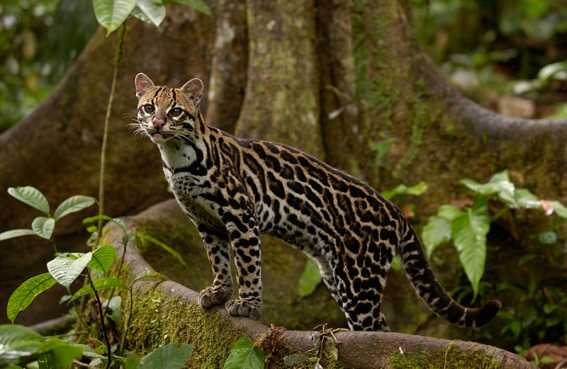

Oncilla

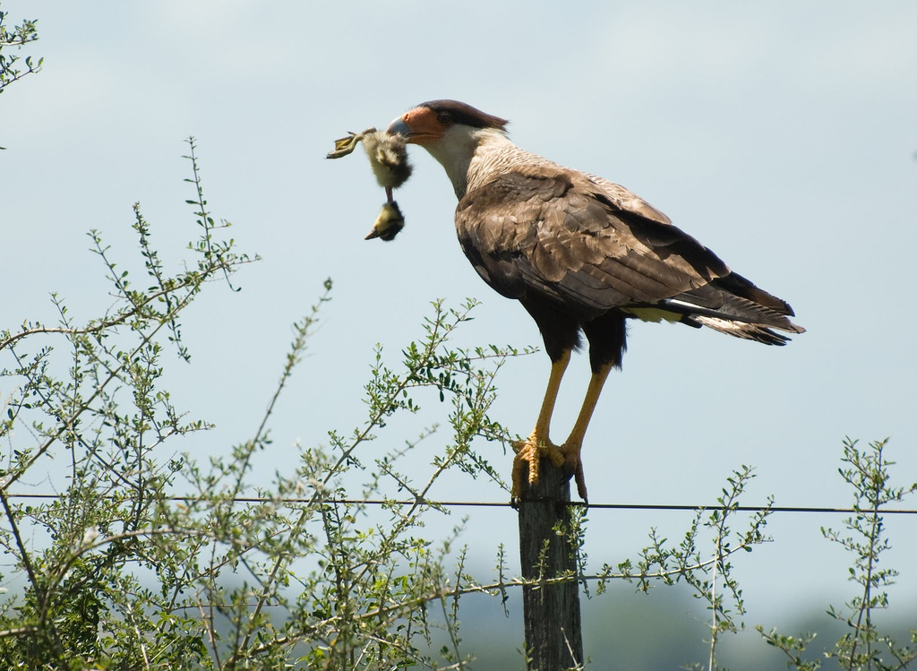

Caracara

The authors also recorded and uploaded the vocal response of the titi monkeys in reponse to each of the four testing conditions: [“Raptor on the ground”](http://rsbl.royalsocietypublishing.org/content/roybiolett/suppl/2013/08/29/rsbl.2013.0535.DC1/Raptor_on_the_ground_first_part.wav), [“Oncilla on the ground”](http://rsbl.royalsocietypublishing.org/content/roybiolett/suppl/2013/08/29/rsbl.2013.0535.DC1/Cat_on_the_ground.wav), [“Raptor in the canopy”](http://rsbl.royalsocietypublishing.org/content/roybiolett/suppl/2013/08/29/rsbl.2013.0535.DC1/Raptor_in_the_canopy.wav), [“Oncilla in the canopy”](http://rsbl.royalsocietypublishing.org/content/roybiolett/suppl/2013/08/29/rsbl.2013.0535.DC1/Cat_in_the_canopy.wav).

In their analyses, the authors first created a set of pie charts to visualize the distribution of call types among the 4 conditions. I will recreate this figure. Then, they used G-tests to test if the observed call sequences are different from the expected call sequence frequencies. I will show you how I tried to replicate these results, but ended up being unable to get similar results. Next, the authors used histograms and Friedman’s tests to compare both call duration and rate to the nature of threat. I will replicate these results as best I can. The following step by the authors was the use of Wilcoxon tests to assess any difference in the time between the first and second call when titis are faced with with a raptor on the ground vs in the canopy, and when titis encounter an oncilla on the ground or in the canopy. They also visualized these results in graphs. I will replicate both the Wilcoxon tests and the graphs.

What I’ll do next is take you through their results, step by step explaining how they analyzed their data - and why - and what the results from these analyses are.

## Loading the datasets!

First, I’ll load in all of the datasets that I will be using throughout my re-analysis. The original file was one Excel file with three sheets of data, here separated into three .csv files. The head(data#) code will show you the first section of these datasets. You can compare them to the original dataset, which you can find in my GitHub repository.

```r
> library(curl)
> f <- curl("https://raw.githubusercontent.com/Callicebus/data-reanalysis-assignment/master/CallType.csv")
> data1 <- read.csv(f, header = TRUE, sep = ",", na.strings = c("", "NA"), stringsAsFactors = TRUE)
> head(data1)
```

```
##       Stimulus Group X1 X2 X3 X4 X5 X6 X7 X8 X9 X10 X11 X12 X13 X14 X15
## 1 Eagle canopy     A  A  A  A  A  A  A  A  A  A   A   A   A   A   A   A
## 2 Eagle canopy     D  A  A  A  A  A  A  A  A  A   A   A   A   A   A   A
## 3 Eagle canopy     M  A  A  A  A  A  A  A  A  A   A   A   A   A   A   A
## 4 Eagle canopy     P  A  A  A  A  A  A  A  A  A   A   A   A   A   A   A
## 5 Eagle canopy     R  A  A  A  A  A  A  A  A  A   O   O   A   O   A   A
## 6 Eagle ground     A  A  A  A  A  A  A  A  A  A   A   A   A   A   A   A
##   X16 X17 X18 X19 X20 X21 X22 X23 X24 X25 X26 X27  X28 X29 X30 Observation
## 1   A   A   A   A   A   A   A   A   A   A   A   A <NA>   A   A        <NA>
## 2   A   A   A   A   S   S   S   S   S   S   S   S    S   S   S        <NA>
## 3   A   A   A   A   A   A   A   A   A   A   A   A    A   A   A        <NA>
## 4   A   A   A   A   A   A   A   A   A   A   A   A    A   A   A        <NA>
## 5   A   A   A   O   A   A   A   A   A   A   A   A    A   A   A        <NA>
## 6   A   A   A   A   A   A   A   B   B   B   C   C    C   B   B        <NA>
##    X
## 1 NA
## 2 NA
## 3 NA
## 4 NA
## 5 NA
## 6 NA
```

```r
> f2 <- curl("https://raw.githubusercontent.com/Callicebus/data-reanalysis-assignment/master/CallInterval.csv")
> data2 <- read.csv(f2, header = TRUE, sep = ",", stringsAsFactors = TRUE)
> head(data2)
```

```
##               X Raptor.up     X.1    X.2    X.3    X.4     X.5 X.6
## 1 Call interval        GA      GD     GM     GP     GR    Mean  NA
## 2           1-2     0.656  1.8079  1.585 0.8126 1.7822 1.32874  NA
## 3           2-3    1.1328  1.2191 1.0422 1.3689 3.1047 1.57354  NA
## 4           3-4    0.8187   1.873 1.5137 0.9003 4.1343   1.848  NA
## 5           4-5    0.5713  2.4207 5.8519 1.4137 1.5108 2.35368  NA
## 6           5-6    0.8726 10.3038  3.063  1.261 2.1485 3.52978  NA
##   Raptor.down    X.7    X.8    X.9   X.10    X.11 X.12 Oncilla.down   X.13
## 1          GA     GD     GM     GP     GR    Mean   NA           GA     GD
## 2      1.2634 2.3956 4.9153 2.6055 3.0869 2.85334   NA       0.3887  0.615
## 3      1.4083  1.365 3.3975 1.5441 2.3368 2.01034   NA       0.3172 0.7331
## 4      0.7163 6.6839 0.6727 1.0903 2.5373  2.3401   NA       0.4432 0.7273
## 5      3.0414 0.5047  0.736 1.7339 4.1408 2.03136   NA       0.4142 0.6397
## 6      3.3212 0.5118 0.3454  3.049 3.5433 2.15414   NA       0.7105 0.5939
##     X.14   X.15   X.16    X.17 X.18 Oncilla.up   X.19   X.20    X.21
```

[output cut: 20 more lines]

```r
> f3 <- curl("https://raw.githubusercontent.com/Callicebus/data-reanalysis-assignment/master/General.csv")
> data3 <- read.csv(f3, header = TRUE, sep = ",", stringsAsFactors = TRUE)
> head(data3)
```

```
##        Stimulus Stimuli Valid       Date  Time Group T.dur.min T.dur.sec
## 1 Raptor canopy       1   Yes  9/25/2008 12:25     A  00:01:00        60
## 2 Raptor canopy       1   Yes  9/19/2008 15:00     D  00:02:04       399
## 3 Raptor canopy       1   Yes  9/14/2009 13:20     M  00:18:29      1109
## 4 Raptor canopy       1   Yes 11/11/2008  9:05     P  00:02:30       150
## 5 Raptor canopy       1   Yes  9/19/2008  8:50     R  00:03:24       204
## 6 Raptor ground       2   Yes   6/9/2010 13:00     A  00:01:17        77
##     Dur.MIN X..calls.1st.min X..individuals Infant calls.ind  X X.1 X.2
## 1  1.000000               44              5      1  8.800000 NA  NA  NA
## 2  6.650000               10              3      0  3.333333 NA  NA  NA
## 3 18.483333               20              4      0  5.000000 NA  NA  NA
## 4  2.500000               39              5      0  7.800000 NA  NA  NA
## 5  3.400000               41              5      0  8.200000 NA  NA  NA
## 6  1.283333               27              6      0  4.500000 NA  NA  NA
##   X.3 X.4 X.5 X.6 X.7
## 1  NA  NA  NA  NA  NA
## 2  NA  NA  NA  NA  NA
## 3  NA  NA  NA  NA  NA
## 4  NA  NA  NA  NA  NA
## 5  NA  NA  NA  NA  NA
## 6  NA  NA  NA  NA  NA
```

## Pie charts - What call types do the titis use?

I’ll start by replicating the pie charts in Figure 1 of the article. In dataset ‘data1’ the authors recorded the call type (call A, B, C or silence) of the first thirty calls in response to the titis encountering the caracara or oncilla models. They then used these data to visualize the monkeys’ responses in pie charts. Even though I think bar charts are a better way of representing these data, I’ll stick to pie charts because I haven’t learned how to make those yet. The authors split their data up in ine pie chart for the first call, one pie chart for calls 2-4, one pie chart for calls 5-15, and one pie chart for calls 16-30. It is not explained exactly why they chose these clusters.

```r
> # Step 1: I will pull the subsets of data from 'data1' that I need for
> # creating each individual pie charts. 'rc' will stand for Raptor in Canopy,
> # 'rg' for Raptor on Ground, 'oc' for Oncilla in Canopy, 'og' for Oncilla on
> # Ground.
>
> # Raptor in Canopy
> rc1 <- data1[1:5, 3]  # Subsetting only the first call of 'raptor in canopy' (rc) part of the dataset.
> rc.count1 <- table(unlist(rc1))  # Counting the caterogical data for the first call
> rcc1 <- as.data.frame(rc.count1)
> rcc1 <- rcc1[!(rcc1$Var1 == "O"), ]  # Removing calls identified as 'Other' because they are not alarm calls.
>
> rc2 <- data1[c(1:5), c(4:6)]  # Subsetting second to fourth call of 'raptor in canopy' part of dataset.
> rc.count2 <- table(unlist(rc2))
> rcc2 <- as.data.frame(rc.count2)
> rcc2 <- rcc2[!(rcc2$Var1 == "O"), ]
>
> rc3 <- data1[c(1:5), c(7:17)]  # Subsetting call 5 to 15 of 'raptor in canopy'.
> rc.count3 <- table(unlist(rc3))
> rcc3 <- as.data.frame(rc.count3)
> rcc3 <- rcc3[!(rcc3$Var1 == "O"), ]
>
> rc4 <- data1[c(1:5), c(18:32)]  # Subsetting call 16 to 30 of 'raptor in canopy'.
> rc.count4 <- table(unlist(rc4))
> rcc4 <- as.data.frame(rc.count4)
> rcc4 <- rcc4[!(rcc4$Var1 == "O"), ]
>
>
> # Raptor on Ground
> rg1 <- data1[6:12, 3]
> rg.count1 <- table(unlist(rg1))
> rgc1 <- as.data.frame(rg.count1)
> rgc1 <- rgc1[!(rgc1$Var1 == "O"), ]
>
> rg2 <- data1[c(6:12), c(4:6)]
> rg.count2 <- table(unlist(rg2))
> rgc2 <- as.data.frame(rg.count2)
> rgc2 <- rgc2[!(rgc2$Var1 == "O"), ]
>
> rg3 <- data1[c(6:12), c(7:17)]
> rg.count3 <- table(unlist(rg3))
> rgc3 <- as.data.frame(rg.count3)
> rgc3 <- rgc3[!(rgc3$Var1 == "O"), ]
>
> rg4 <- data1[c(6:12), c(18:32)]
> rg.count4 <- table(unlist(rg4))
> rgc4 <- as.data.frame(rg.count4)
> rgc4 <- rgc4[!(rgc4$Var1 == "O"), ]
> colnames(rgc4) <- c("Call", "Freq")  # I want to only have a legend with the last pie chart, it is redundant to have one at each chart. However, I want the frst column to be called 'CallType' rather than 'Var1'.
>
> # Oncilla on Ground
> og1 <- data1[13:17, 3]
> og.count1 <- table(unlist(og1))
> ogc1 <- as.data.frame(og.count1)
> ogc1 <- ogc1[!(ogc1$Var1 == "O"), ]
>
> og2 <- data1[c(13:17), c(4:6)]
> og.count2 <- table(unlist(og2))
> ogc2 <- as.data.frame(og.count2)
> ogc2 <- ogc2[!(ogc2$Var1 == "O"), ]
>
> og3 <- data1[c(13:17), c(7:17)]
> og.count3 <- table(unlist(og3))
> ogc3 <- as.data.frame(og.count3)
> ogc3 <- ogc3[!(ogc3$Var1 == "O"), ]
>
> og4 <- data1[c(13:17), c(18:32)]
> og.count4 <- table(unlist(og4))
> ogc4 <- as.data.frame(og.count4)
> ogc4 <- ogc4[!(ogc4$Var1 == "O"), ]
>
>
> # Oncilla in Canopy
> oc1 <- data1[18:23, 3]
> oc.count1 <- table(unlist(oc1))
> occ1 <- as.data.frame(oc.count1)
> occ1 <- occ1[!(occ1$Var1 == "O"), ]
>
> oc2 <- data1[c(18:23), c(4:6)]
> oc.count2 <- table(unlist(oc2))
> occ2 <- as.data.frame(oc.count2)
> occ2 <- occ2[!(occ2$Var1 == "O"), ]
>
> oc3 <- data1[c(18:23), c(7:17)]
> oc.count3 <- table(unlist(oc3))
> occ3 <- as.data.frame(oc.count3)
> occ3 <- occ3[!(occ3$Var1 == "O"), ]
>
> oc4 <- data1[c(18:23), c(18:32)]
> oc.count4 <- table(unlist(oc4))
> occ4 <- as.data.frame(oc.count4)
> occ4 <- occ4[!(occ4$Var1 == "O"), ]
```

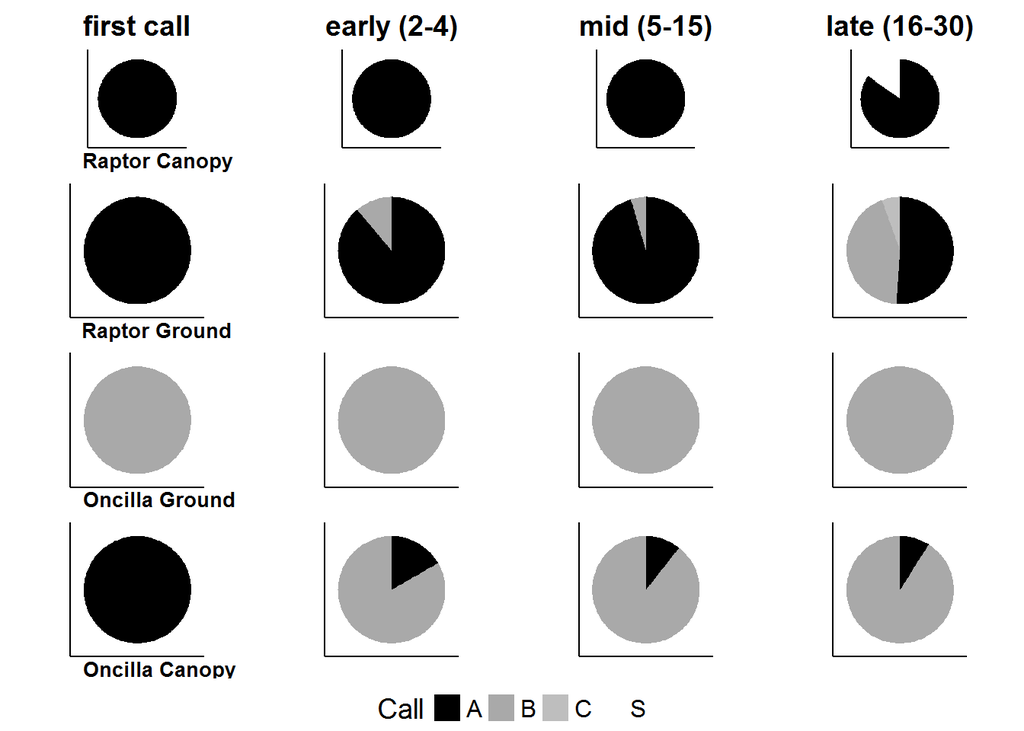

```r
> # Step 2: Creating pie charts for each of the subsets of data.
>
> # Opening some necessary packages
> library(ggplot2)
> library(gridExtra)
> library(cowplot)  # The package 'cowplot' is an extension of ggplot2 and helps you create graphs that are ready for publication!
> # This function below helps me to pull a legend from the pie.rg4 chart, save
> # that separately as a grob in 'legend', so I can add it underneath all pie
> # charts with the code grid.arrange() later on!
> library(gridExtra)
> get_legend <- function(myggplot) {
+     tmp <- ggplot_gtable(ggplot_build(myggplot))
+     leg <- which(sapply(tmp$grobs, function(x) x$name) == "guide-box")
+     legend <- tmp$grobs[[leg]]
+     return(legend)
+ }
>
> # The 'myPalette' code below makes sure that Type A calls are always colored
> # black, Type B calls always dark grey, etc.
> myPalette <- c(A = "black", B = "darkgrey", C = "grey", S = "white")
>
> # Pie charts for 'Raptor in Canopy'.
> pie.rc1 <- ggplot(rcc1, aes(x = "", y = Freq, fill = Var1)) + geom_bar(width = 1,
+     stat = "identity") + coord_polar("y", start = 0) + theme(legend.position = "none",
+     axis.title.x = element_blank(), axis.title.y = element_blank(), axis.text = element_blank(),
+     axis.ticks = element_blank(), panel.grid = element_blank(), panel.background = element_rect(colour = "black")) +
+     scale_fill_manual(values = myPalette) + ggtitle("first call")
>
> pie.rc2 <- ggplot(rcc2, aes(x = "", y = Freq, fill = Var1)) + geom_bar(width = 1,
+     stat = "identity") + coord_polar("y", start = 0) + theme(legend.position = "none",
+     axis.title.x = element_blank(), axis.title.y = element_blank(), axis.text = element_blank(),
+     axis.ticks = element_blank(), panel.grid = element_blank(), panel.background = element_rect(colour = "black")) +
+     scale_fill_manual(values = myPalette) + ggtitle("early (2-4)")
>
> pie.rc3 <- ggplot(rcc3, aes(x = "", y = Freq, fill = Var1)) + geom_bar(width = 1,
+     stat = "identity") + coord_polar("y", start = 0) + theme(legend.position = "none",
+     axis.title.x = element_blank(), axis.title.y = element_blank(), axis.text = element_blank(),
+     axis.ticks = element_blank(), panel.grid = element_blank(), panel.background = element_rect(colour = "black")) +
+     scale_fill_manual(values = myPalette) + ggtitle("mid (5-15)")
>
> pie.rc4 <- ggplot(rcc4, aes(x = "", y = Freq, fill = Var1)) + geom_bar(width = 1,
+     stat = "identity") + coord_polar("y", start = 0) + theme(legend.position = "none",
+     axis.title.x = element_blank(), axis.title.y = element_blank(), axis.text = element_blank(),
+     axis.ticks = element_blank(), panel.grid = element_blank(), panel.background = element_rect(colour = "black")) +
+     scale_fill_manual(values = myPalette) + ggtitle("late (16-30)")
>
>
> # Pie charts for 'Raptor on Ground'.
> pie.rg1 <- ggplot(rgc1, aes(x = "", y = Freq, fill = Var1)) + geom_bar(width = 1,
+     stat = "identity") + coord_polar("y", start = 0) + theme(legend.position = "none",
+     axis.title.x = element_blank(), axis.title.y = element_blank(), axis.text = element_blank(),
+     axis.ticks = element_blank(), panel.grid = element_blank(), panel.background = element_rect(colour = "black")) +
+     scale_fill_manual(values = myPalette)
>
> pie.rg2 <- ggplot(rgc2, aes(x = "", y = Freq, fill = Var1)) + geom_bar(width = 1,
+     stat = "identity") + coord_polar("y", start = 0) + theme(legend.position = "none",
+     axis.title.x = element_blank(), axis.title.y = element_blank(), axis.text = element_blank(),
+     axis.ticks = element_blank(), panel.grid = element_blank(), panel.background = element_rect(colour = "black")) +
+     scale_fill_manual(values = myPalette)
>
> pie.rg3 <- ggplot(rgc3, aes(x = "", y = Freq, fill = Var1)) + geom_bar(width = 1,
+     stat = "identity") + coord_polar("y", start = 0) + theme(legend.position = "none",
+     axis.title.x = element_blank(), axis.title.y = element_blank(), axis.text = element_blank(),
+     axis.ticks = element_blank(), panel.grid = element_blank(), panel.background = element_rect(colour = "black")) +
+     scale_fill_manual(values = myPalette)
>
> pie.rg4 <- ggplot(rgc4, aes(x = "", y = Freq, fill = Call)) + geom_bar(width = 1,
+     stat = "identity") + coord_polar("y", start = 0) + theme(legend.position = "bottom",
+     axis.title.x = element_blank(), axis.title.y = element_blank(), axis.text = element_blank(),
+     axis.ticks = element_blank(), panel.grid = element_blank(), panel.background = element_rect(colour = "black")) +
+     scale_fill_manual(values = myPalette)
> legend <- get_legend(pie.rg4)
> pie.rg4 <- pie.rg4 + theme(legend.position = "none")
>
>
> # Pie charts 'Oncilla on Ground'
> pie.og1 <- ggplot(ogc1, aes(x = "", y = Freq, fill = Var1)) + geom_bar(width = 1,
+     stat = "identity") + coord_polar("y", start = 0) + theme(legend.position = "none",
+     axis.title.x = element_blank(), axis.title.y = element_blank(), axis.text = element_blank(),
+     axis.ticks = element_blank(), panel.grid = element_blank(), panel.background = element_rect(colour = "black")) +
+     scale_fill_manual(values = myPalette)
>
> pie.og2 <- ggplot(ogc2, aes(x = "", y = Freq, fill = Var1)) + geom_bar(width = 1,
+     stat = "identity") + coord_polar("y", start = 0) + theme(legend.position = "none",
+     axis.title.x = element_blank(), axis.title.y = element_blank(), axis.text = element_blank(),
+     axis.ticks = element_blank(), panel.grid = element_blank(), panel.background = element_rect(colour = "black")) +
+     scale_fill_manual(values = myPalette)
>
> pie.og3 <- ggplot(ogc3, aes(x = "", y = Freq, fill = Var1)) + geom_bar(width = 1,
+     stat = "identity") + coord_polar("y", start = 0) + theme(legend.position = "none",
+     axis.title.x = element_blank(), axis.title.y = element_blank(), axis.text = element_blank(),
+     axis.ticks = element_blank(), panel.grid = element_blank(), panel.background = element_rect(colour = "black")) +
+     scale_fill_manual(values = myPalette)
>
> pie.og4 <- ggplot(ogc4, aes(x = "", y = Freq, fill = Var1)) + geom_bar(width = 1,
+     stat = "identity") + coord_polar("y", start = 0) + theme(legend.position = "none",
+     axis.title.x = element_blank(), axis.title.y = element_blank(), axis.text = element_blank(),
+     axis.ticks = element_blank(), panel.grid = element_blank(), panel.background = element_rect(colour = "black")) +
+     scale_fill_manual(values = myPalette)
>
>
> # Pie charts 'Oncilla in Canopy'
> pie.oc1 <- ggplot(occ1, aes(x = "", y = Freq, fill = Var1)) + geom_bar(width = 1,
+     stat = "identity") + coord_polar("y", start = 0) + theme(legend.position = "none",
+     axis.title.x = element_blank(), axis.title.y = element_blank(), axis.text = element_blank(),
+     axis.ticks = element_blank(), panel.grid = element_blank(), panel.background = element_rect(colour = "black")) +
+     scale_fill_manual(values = myPalette)
>
> pie.oc2 <- ggplot(occ2, aes(x = "", y = Freq, fill = Var1)) + geom_bar(width = 1,
+     stat = "identity") + coord_polar("y", start = 0) + theme(legend.position = "none",
+     axis.title.x = element_blank(), axis.title.y = element_blank(), axis.text = element_blank(),
+     axis.ticks = element_blank(), panel.grid = element_blank(), panel.background = element_rect(colour = "black")) +
+     scale_fill_manual(values = myPalette)
>
> pie.oc3 <- ggplot(occ3, aes(x = "", y = Freq, fill = Var1)) + geom_bar(width = 1,
+     stat = "identity") + coord_polar("y", start = 0) + theme(legend.position = "none",
+     axis.title.x = element_blank(), axis.title.y = element_blank(), axis.text = element_blank(),
+     axis.ticks = element_blank(), panel.grid = element_blank(), panel.background = element_rect(colour = "black")) +
+     scale_fill_manual(values = myPalette)
>
> pie.oc4 <- ggplot(occ4, aes(x = "", y = Freq, fill = Var1)) + geom_bar(width = 1,
+     stat = "identity") + coord_polar("y", start = 0) + theme(legend.position = "none",
+     axis.title.x = element_blank(), axis.title.y = element_blank(), axis.text = element_blank(),
+     axis.ticks = element_blank(), panel.grid = element_blank(), panel.background = element_rect(colour = "black")) +
+     scale_fill_manual(values = myPalette)
>
> # I'd like to get all 16 pie charts in a row, like in Figure 1 of the
> # article. To do so, I'll first use the plot_grid() command, which lets you
> # organize your graphs and add labels to them.
> totalplot <- plot_grid(pie.rc1, pie.rc2, pie.rc3, pie.rc4, pie.rg1, pie.rg2,
+     pie.rg3, pie.rg4, pie.og1, pie.og2, pie.og3, pie.og4, pie.oc1, pie.oc2,
+     pie.oc3, pie.oc4, labels = c("Raptor Canopy", " ", " ", " ", "Raptor Ground",
+         " ", " ", " ", "Oncilla Ground", " ", " ", " ", "Oncilla Canopy", " ",
+         " ", " ", ncol = 4, nrow = 4), label_size = 10, hjust = -0.5, vjust = 10.5)
>
> # grid.arrange() is a cool little code! It lets you arrange graphs within a
> # table-like structure, so that you can use it to place the legend (which we
> # saved in 'legend' earlier) just once underneath all your pie charts rather
> # than with each individual chart! Less clutter!
> grid.arrange(totalplot, legend, nrow = 2, heights = c(30, 2))
```

If I’d had more time (i.e. started this assignment earlier…) I would have liked to find out how I can make sure the graph title on the top 4 pie charts doesn’t affect the size of the charts (they are currently slightly smaller than the rest due to title placement). For comparison below you’ll see Figure 1 as published in the article. The charts produces with the code above seem to be pretty accurate when compared to Figure 1 in the article.

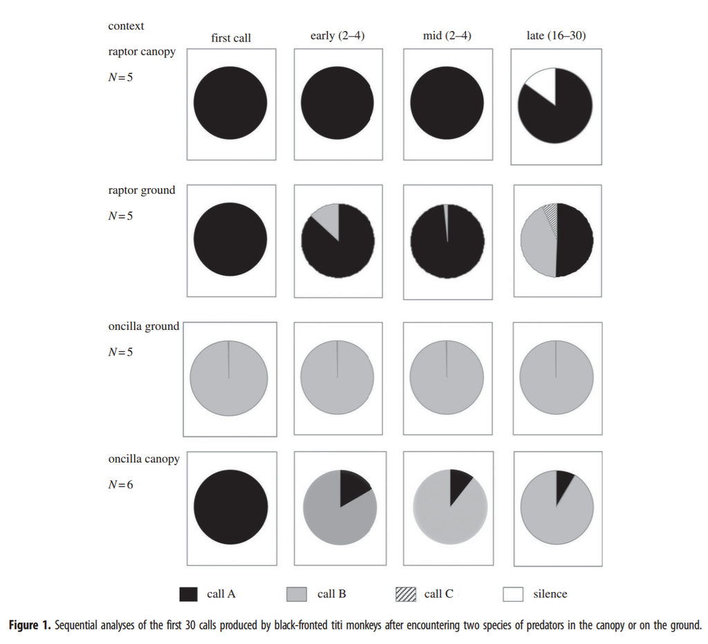

## G-test - observed vs. expected call sequence frequencies

Next, the authors used a G-test to find out if the observed call sequences are different from the expected call frequencies. In the article the authors sugges that they use Table S2, a contingency table, to conduct these G-tests.

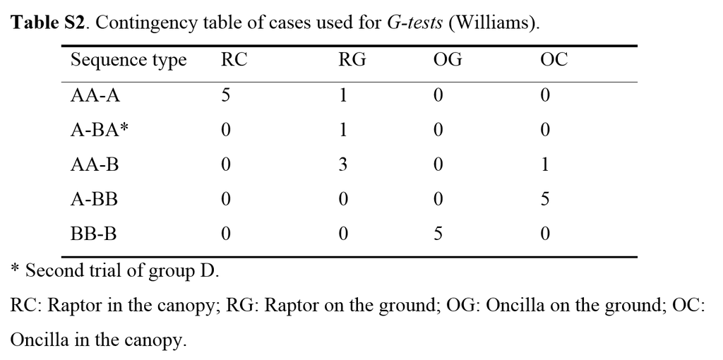

A G-test in R can be done through the GTest() function, which is part of the DescTools package. An exampe is below, using data from Table S2:

```r
> library(DescTools)
> observed <- c(5, 1, 3)  # Observed frequencies
> expected <- c(rep(1/3, 3))  # Expected proportions
>
> GTest(x = observed, p = expected, correct = "williams")
```

```
##
##  Log likelihood ratio (G-test) goodness of fit test
##
## data:  observed
## G = 2.7103, X-squared df = 2, p-value = 0.2579
```

One can also do this without the DescTools package by using the following code:

```r
> observed <- c(5, 1, 3)
> expected <- c(rep(1/3, 3))
>
> degrees <- 2  # Degrees of freedom
> expected.count <- sum(observed) * expected
> G <- 2 * sum(observed * log(observed/expected.count))  # Calculting G-value
> G
```

```
## [1] 2.911032
```

```r
> pchisq(G, df = degrees, lower.tail = FALSE)  # Using that G-value to get to th p-value.
```

```
## [1] 0.23328
```

## Histograms of call duration and rate vs. nature of threat

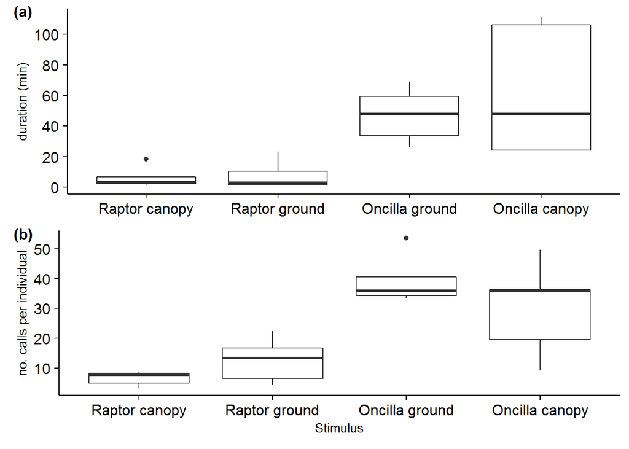

```r
> # This first snippet of code makes R follow the order in which the 4 test
> # conditions appear in the dataset. Without this code, my boxplots were
> # ordered alphabetically, and thus organized exactly opposite of what was
> # shown in Figure 2.
> data3$Stimulus = factor(data3$Stimulus, unique(data3$Stimulus))
>
> # I only selected rows 1 to 20 because the last 2 rows of data were invalid
> # records, and thus need to be kept out of the analysis.
> boxplot <- ggplot(data3[1:20, ], aes(Stimulus, Dur.MIN)) + geom_boxplot() +
+     theme(text = element_text(size = 10), axis.text.x = element_text(angle = 0),
+         panel.background = element_rect(fill = "white"), axis.line.x = element_line(color = "black",
+             size = 0.5), axis.line.y = element_line(color = "black", size = 0.5),
+         legend.position = "none", axis.title.x = element_blank()) + scale_y_continuous(breaks = seq(0,
+     120, 20)) + labs(y = "duration (min)")
>
> boxplot2 <- ggplot(data3[1:20, ], aes(Stimulus, calls.ind)) + geom_boxplot() +
+     theme(text = element_text(size = 10), axis.text.x = element_text(angle = 0),
+         panel.background = element_rect(fill = "white"), axis.line.x = element_line(color = "black",
+             size = 0.5), axis.line.y = element_line(color = "black", size = 0.5)) +
+     scale_y_continuous(breaks = seq(0, 60, 10)) + labs(y = "no. calls per individual")
>
> # Again by using plot_grid() you can organize your graphs in such a way that
> # they nearly perfectly compare to those in Figure 2. I just cannot find out
> # how to change their height in plot_grid()!
> plot_grid(boxplot, boxplot2, labels = c("(a)", "(b)"), ncol = 1, nrow = 2, label_size = 12)
```

Figure 2 as in the article, for comparison:

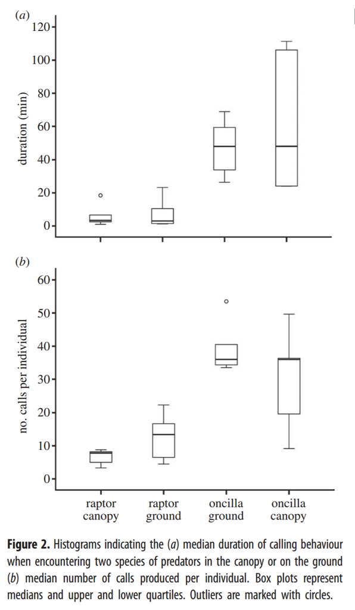

When looking at these histograms it becomes apparent that titis respond very different to encountering an oncilla than to encountering a caracara. Both duration and the number of calls per individual are much higher when an oncilla is encountered than when a caracara is encountered. What this means depends on the behavior of the primates once they stop vocalizing in case of the caracara. Do they resume daily business, or do they keep quiet and hide? In the first case it could suggest that titis don’t feel as threatened by the presence of a caracara when compared to the presence of an oncilla. Strangely enough, the authors do not mention these results in their discussion at all. I felt at the least they should have discussed if and why the caracara is or is not a good predator model in this study.

## Friedman Tests - Do duration and # of alarm calls vary with the nature of the threat?

To confirm the histogram results with statistics, the auhors conducted Friedman tests. First, this is the Friedman test for differences in duration of the calls between the four conditions.

```r
> # Cutting the two invalid datapoints from dataset:
> data3.1 <- data3[-c(21:23), ]
>
> # Friedman Test does not work if you don't change your group and block
> # variables into factors.
> data3.1$Stimulus <- factor(data3.1$Stimulus)
> data3.1$Group <- factor(data3.1$Group)
>
> # Friedman test:
> friedman.test(data3.1$Dur.MIN ~ Stimulus | Group, data3.1)
```

```
##
##  Friedman rank sum test
##
## data:  data3.1$Dur.MIN and Stimulus and Group
## Friedman chi-squared = 12.12, df = 3, p-value = 0.006983
```

This first Friedman Test gets me the same *X* <sup>2</sup> value of 12.120 as in the paper, but my *p*-value of 0.006 is different than their *p*-value of 0.001. I’m not sure why, as the previous histograms of the same data and *X* <sup>2</sup>-values do match up.

Secondly, a Friedman test for the differences in number of calls per individual in the four conditions.

```r
> friedman.test(data3.1$calls.ind ~ Stimulus | Group, data3.1)
```

```
##
##  Friedman rank sum test
##
## data:  data3.1$calls.ind and Stimulus and Group
## Friedman chi-squared = 12.12, df = 3, p-value = 0.006983
```

Here the same issue returns: all data match up except for the *p*-value. Not really sure why.

## Wilcoxon Tests

To determine if these differences we saw in the histograms and Friedmans tests between raptors and oncillas are signifcant, the authors conducted a Wilcoxon test.

```r
> wilcox.test(data3.1$Dur.MIN[11:20] - data3.1$Dur.MIN[1:10], alternative = "two.sided")
```

```
##
##  Wilcoxon signed rank test
##
## data:  data3.1$Dur.MIN[11:20] - data3.1$Dur.MIN[1:10]
## V = 55, p-value = 0.001953
## alternative hypothesis: true location is not equal to 0
```

```r
> wilcox.test(data3.1$calls.ind[11:20] - data3.1$calls.ind[1:10], alternative = "two.sided")
```

```
##
##  Wilcoxon signed rank test
##
## data:  data3.1$calls.ind[11:20] - data3.1$calls.ind[1:10]
## V = 55, p-value = 0.001953
## alternative hypothesis: true location is not equal to 0
```

The results are equal for call duration and rate of calling. I get a V of 55, which is the same as te *z*-score of 55 reported in the paper. In both my analysis and that in the paper *n* = 10, but the *p*-value mentioned in the article is 0.006, whereas mine is *p* = 0.002. Either way, the results show that there is a significant difference in both call duration and rate between titis encountering an oncilla or caracara. Both calling duration and rate are lower for encountering caracaras.

Last, the authors conducted Wilcoxon tests to assess any difference in the time between the first and second call when titis are faced with with a raptor on the ground vs in the canopy, and when titis encounter an oncilla on the ground or in the canopy.

```r
> # First you'll need to install and/or load the package 'Coin' to run
> # wilcoxsign_test(), because this time we want an exact test and
> # wilcox.test() does not offer that option.
> library(coin)
> mdata2 <- t(data2)  # First I want to transpose these data 'data2' so that they are easier for me to work with.
>
> # Wilcoxon Exact test for 'Raptor in Canopy' versus 'Raptor on Ground'.
> rc.int <- as.numeric(c(mdata2[2:6, 2]))  # Now I select only the call interval times for 'Raptor in Canopy'.
> rg.int <- as.numeric(c(mdata2[9:13, 2]))  # Select call interval times for 'Raptor on Ground'.
> wilcoxsign_test(rc.int ~ rg.int, distribution = "exact")
```

```
##
##  Exact Wilcoxon-Pratt Signed-Rank Test
##
## data:  y by x (pos, neg)
##   stratified by block
## Z = -2.0226, p-value = 0.0625
## alternative hypothesis: true mu is not equal to 0
```

```r
> # Wilcoxon Exact test for 'Oncilla in Canopy' versus 'Oncilla on Ground'.
> og.int <- as.numeric(c(mdata2[16:20, 2]))
> oc.int <- as.numeric(c(mdata2[23:27, 2]))
> wilcoxsign_test(oc.int ~ og.int, distribution = "exact")
```

```
##
##  Exact Wilcoxon-Pratt Signed-Rank Test
##
## data:  y by x (pos, neg)
##   stratified by block
## Z = 2.0226, p-value = 0.0625
## alternative hypothesis: true mu is not equal to 0
```

The resuls of both these tests match with those presented in the paper. I get a *z*-value of -2.023 and an exact *p*-value of 0.063.

The authors also present these data in a graph in Figure S3 in the supplementary data:

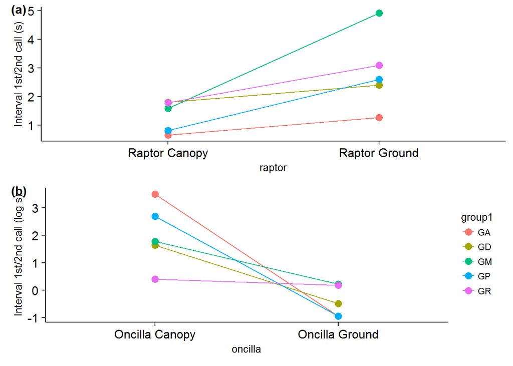

```r
> # The 'myPalette' code below makes sure that Type A calls are always colored
> # black, Type B calls always dark grey, etc.
> myPalette2 <- c(A = "black", D = "yellow", GM = "green", GP = "blue", GR = "pink")
>
> # The next 4 lines create a dataframe that I can use to recreate Figure S3.
> raptor <- c(rep("Raptor Canopy", 5), rep("Raptor Ground", 5))
> raptor.int <- c(rc.int, rg.int)
> group1 <- as.character(c(mdata2[2:6, 1]))
> df1 <- data.frame(raptor, group1, raptor.int)
>
> # Now that I have all data I need in 1 dataframe, I can create the graph:
> plot1 <- ggplot(df1, aes(x = raptor, y = raptor.int, color = group1, group = group1)) +
+     geom_line() + geom_point(size = 3) + labs(y = "Interval 1st/2nd call (s)") +
+     theme(text = element_text(size = 10), legend.position = "none") + scale_fill_manual(values = myPalette2)
>
>
> # Then I'll do the same for the Oncilla data:
> oncilla <- c(rep("Oncilla Canopy", 5), rep("Oncilla Ground", 5))
> oncilla.int <- c(oc.int, og.int)
> oncilla.int <- log(oncilla.int)  # Authors took logarithm of the interval data.
>
> group1 <- as.character(c(mdata2[2:6, 1]))
> df2 <- data.frame(oncilla, group1, oncilla.int)
> plot2 <- ggplot(df2, aes(x = oncilla, y = oncilla.int, color = group1, group = group1)) +
+     geom_line() + geom_point(size = 3) + labs(y = "Interval 1st/2nd call (log s)") +
+     theme(text = element_text(size = 10)) + scale_fill_manual(values = myPalette2)
>
>
> plot_grid(plot1, plot2, labels = c("(a)", "(b)"), ncol = 1, nrow = 2, label_size = 12)
```

As you can see in comparison Figure S3 from the supplementary material, my graphs have turned out the same, except for that Oncilla Ground and Oncilla Canopy have been reversed in positions in my second graph. I had used a code to try to fix that (the one that worked in an earlier section of this report), but it wouldn’t work this time. Anyhow, these graphs make it clear, more clearly than the previous Wilxocon tests, that the interval between the 1st and 2nd call is always longer then raptors are seen on the ground rather than in the canopy. For Oncillas the result is the opposite: there is a longer interval between the 1st and 2nd call when oncillas were discovered in the canopy in comparison to on the ground.

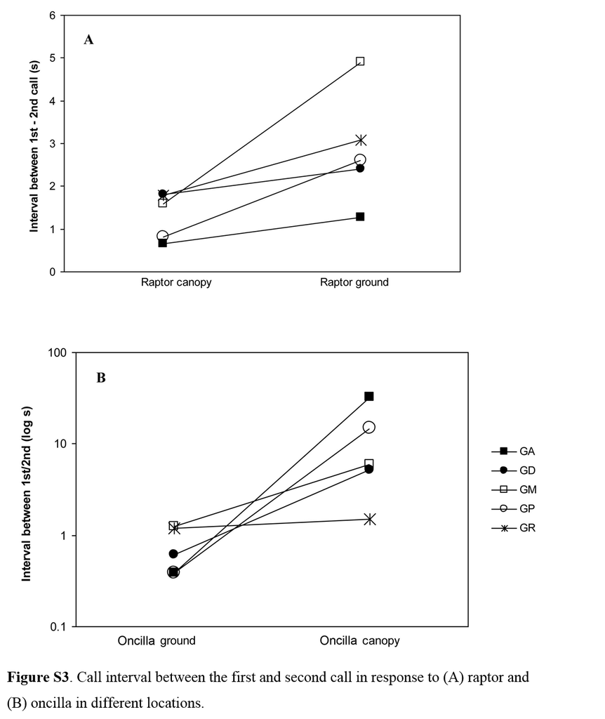

This study shows that when titi monkeys discover an oncilla or caracara in an uncharacteristic location (so Raptor on Ground or Oncilla in Canopy) they modify their initial call sequence, as well as the duration and rate at which the monkeys are alarm calling. The authors state that titi monkeys thus encode information about predator type an location in their calls. I’m not sure I agree with their conclusion, because how often are titis really going to see caracaras on the forest floor and oncillas in trees!? Maybe these results just show that they recognize the type of predator, but are confused about what exactly is going on.

In general, I think the data show that the monkeys are much more alarmed by the presence of an oncilla than a caracara. I wonder what would have happened had they used a Harpy eagle model instead of a caracara model!